# Duplicate and Missing Cases

lindbrook

2016-09-25

## Overview

John Snow’s map of the 1854 cholera outbreak in London is a canonical example of data visualization:[^1]

[figure not shown]

In 1992, Rusty Dodson and Waldo Tobler digitized the map. While the original data are no longer available,[^2] they are preserved in Michael Friendly’s *HistData* R package. Those data are plotted below:

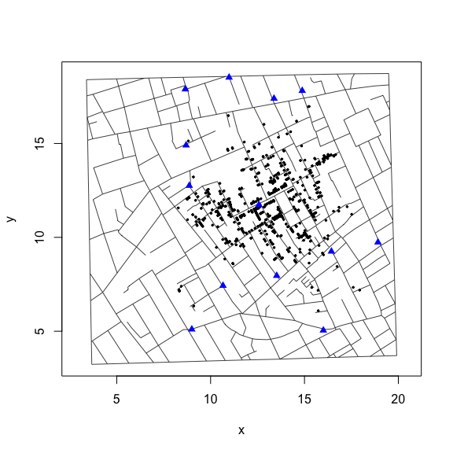

However, there are two apparent coding errors, which stem from three misplaced cases.

While the data record 578 bars, only 575 of them have a unique x-y coordinate.[^3] Three pairs have identical coordinates: 1) 93 and 214; 2) 91 and 241; and 3) 209 and 429. Within the scheme of stacking bars to represent the fatality count, this cannot occur. All bars should have a unique x-y coordinate. For this reason, duplicates are likely to be coding errors.

```r
duplicates <- Snow.deaths[(duplicated(Snow.deaths[, c("x", "y")])), ]

duplicates.id <- lapply(duplicates$x, function(i) {
  Snow.deaths[Snow.deaths$x == i, "case"]
})

Snow.deaths[unlist(duplicates.id), ]
```

```
#>     case        x        y
#> 93    93 12.84460 11.61027
#> 214  214 12.84460 11.61027
#> 91    91 12.65285 11.26382
#> 241  241 12.65285 11.26382
#> 209  209 12.68321 11.28437
#> 429  429 12.68321 11.28437
```

Fortunately, a careful comparison of Snow’s map and the map generated by Dodson and Tobler’s data reveals that there are three “missing” bars in the latter. An expedient “fix” would be to use the duplicate observations to fill in for the “missing” bars:

```r
fatalities <- Snow.deaths

fix <- data.frame(x = c(12.56974, 12.53617, 12.33145), y = c(11.51226, 11.58107, 14.80316))

fatalities[c(91, 93, 209), c("x", "y")] <- fix
```

This fixed data set is available as *fatalities* in the package and as *Snow.deaths2* in Michael Friendly’s package (>= ver. 0.7-8). For those interested, an explanation of how I arrived at the values follows.

## Duplicate Cases: Cambridge Street

The three pairs of duplicates lie at two locations on opposite sides of Cambridge Street:

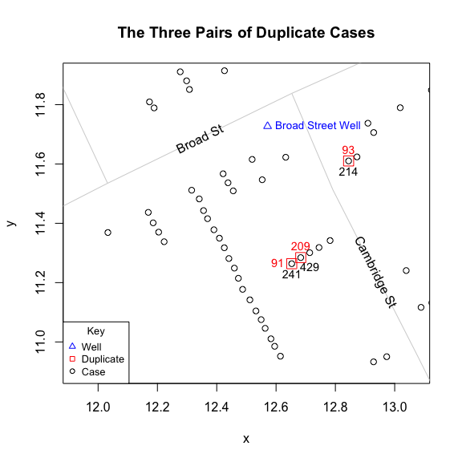

## Missing Cases: Broad Street

40 Broad Street, which lies just southwest (below and left) of the Broad Street pump and which is the accepted home of the index case, is the location of two of the “missing” cases.

Snow’s map shows four “bars” or cases:

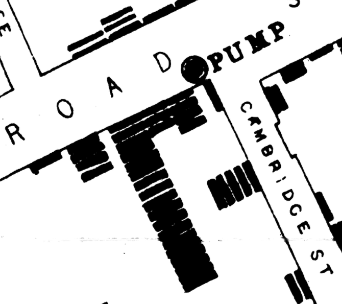

But Dodson and Tobler’s data show only two, cases 32 and 122. Furthermore, the two cases also appear to be farther apart than what we see in neighboring stacks:

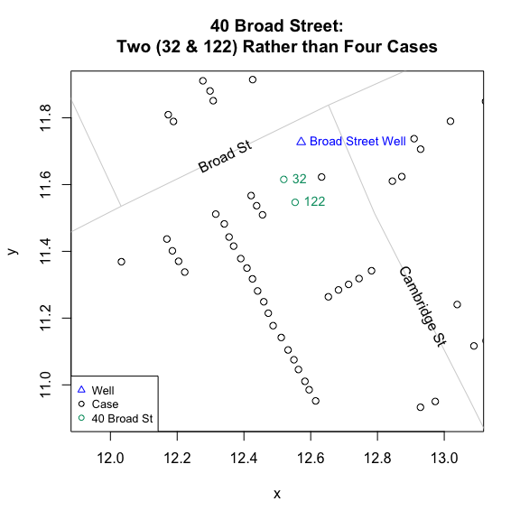

## Missing Cases: Noel Street

Snow’s map shows three cases at the end of Noel Street:

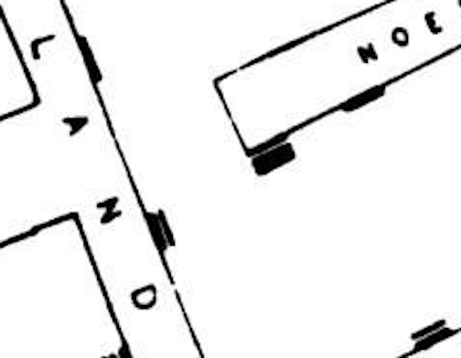

But Dodson and Tobler’s data shows only two, cases 282 and 422. They also appear to be farther apart than what we see in neighboring stacks:

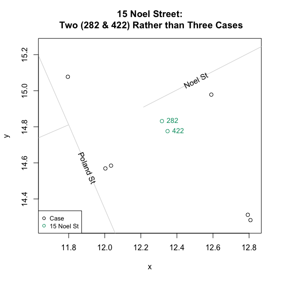

## A Solution

One solution to these problems is to use the three duplicate observations from Cambridge Street to fill in for the three “missing” observations on Broad and Noel Streets. This is both plausible and reasonable.

What makes this plausible is that with the exception of the x-y coordinate of the case at the base of stack, the remaining coordinates, which make up 44% (257/578) of all bars and which include the proposed locations for the three “missing” observations, do not represent the location of a case. They only serve to align bars within a stack. For this reason, putting aside concerns about alignment or the number of bars, there should be no objections about moving this class of bars.

What makes this reasonable is that I do not relocate bars by hand. Instead, I use geometric interpolation. The basic idea is straightforward: use existing observations in a stack to determine the “standard” *unit* distance between bars; then use multiples of the *unit* distance to position “missing” observations.

As an example, consider 40 Broad Street. On Snow’s map, there are four cases but in Dodson and Tobler there are just two. Visual inspection leads me to make three claims: 1) the distance between the two observed cases, 32 and 122, is greater than neighboring sites; 2) there appears to be room for just one “missing” case between 32 and 122; and 3) the other “missing” case should be located just beyond case 122. The proposed coordinates are illustrated below:

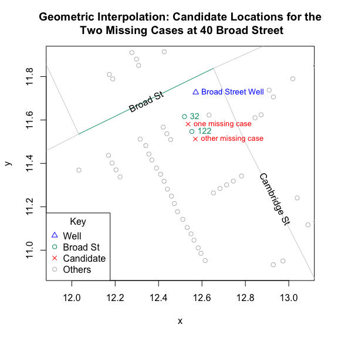

## Geometric interpolation: *unit* distance

To explain how I got these coordinates, I first focus on the computation of the *unit* distance in one dimension and then I will move to the general two dimensional case. Again, I use 40 Broad Street as the example.

To illustrate the computation the *unit* distance, I simplify things by rotating the data so that the stack lies in a single dimension (horizontal). Thus, to implement my claim that only one “missing” case fits between cases 32 and 122 I set the *unit* distance between the two observed cases to 2:

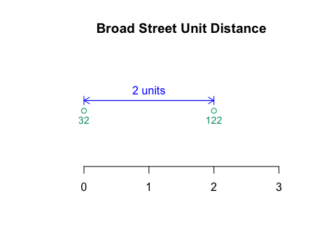

I then place one “missing” case 1 *unit* away from 32:

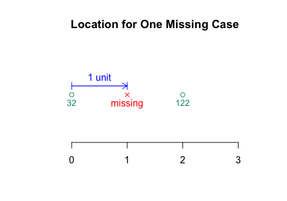

And place the other “missing” case three *units* away:

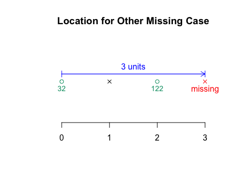

## Geometric interpolation: in 2 dimensions

Because stacks typically lie in two dimensional space and because we need to respect features like roads and addresses, the actual interpolation is a bit more complicated than the above suggests.

Consider the example of the “missing” observation that lies between cases 32 and 122. Just as with the one dimensional example above, the “missing” observation should be located one *unit* away from case 32. The difference in two dimensions is that it needs to be located one *unit* away from case 32 (at the red “x”) as measured along the line that runs through the stack’s axis (black dotted line).

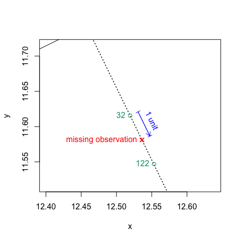

To compute the coordinates for the “missing” case, I use geometry to find the points of intersection between a circle and line. The circle is simple: its center is the reference point (case 32), and its radius is the desired multiple of the *unit* distance, which is 1 in this example. The line is more complicated: it is the line that runs through the stack’s central axis.

What makes the line complicated is that, essentially, none of the bars in any of the stacks in Dodson and Tobler are perfectly aligned. To ensure that there is only one unique axis for any stack, I impose two constraints: 1) a stack must lie along an axis that is orthogonal to the road (segment) where the stack is located[^4]; and 2) the axis must pass through the reference point, the bar at the base of the stack (the bar closest to the stack’s home road segment).

As a consequence, the line drawn through the stack’s axis will pass through the circle’s center, which is also the reference point:

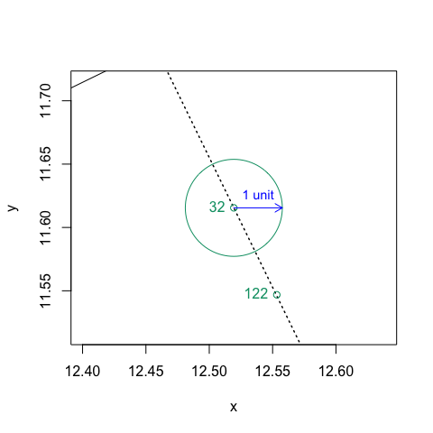

This means that there will always be two points of intersection (red squares):

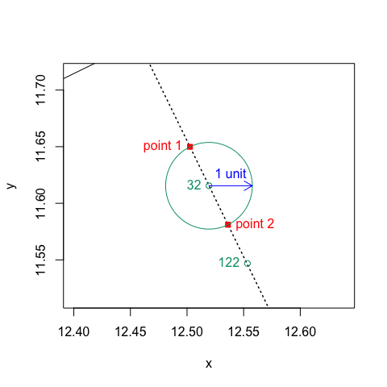

Thus, finding the coordinates of the “missing” observations boils down to solving a quadratic equation. I do so using the formulas below:

```r
# Equation of line for the "home" road segment
# "segment" is the numeric ID of one of the 528 sets of line segments in Dodson and Tobler
segmentOLS <- function(segment) {
  lm(y ~ x, data = street.list[[segment]])
}

# Slope for orthogonal stack axis
orthogonalSlope <- function(segment) {
  ols <- segmentOLS(segment)
  -1 / coef(ols)[2]
}

# Intercept for orthogonal stack axis
# "case" if the reference point of a stack
orthogonalIntercept <- function(case, segment) {
  Snow.deaths[case, "y"] - orthogonalSlope(segment) * Snow.deaths[case, "x"]
}

# unit distance is a function of the Euclidean distance between "case1" and "case2"
unitDistance <- function(case1, case2) {
  dist(Snow.deaths[c(case1, case2), c("x", "y")])
}

# Quadratic equation
quadratic <- function(a, b, c) {
  root1 <- (-b + sqrt(b^2 - 4 * a * c)) / (2 * a)
  root2 <- (-b - sqrt(b^2 - 4 * a * c)) / (2 * a)
  c(root1, root2)
}

# Geometric interpolation
# "multiplier" scales and defines the unit distance
interpolatedPoints <- function(case1, case2, multiplier = 0.5, segment) {
  p <- Snow.deaths[case1, "x"]
  q <- Snow.deaths[case1, "y"]
  radius <- multiplier * unitDistance(case1, case2)
  m <- orthogonalSlope(segment)
  b <- orthogonalIntercept(case1)
  A <- (m^2 + 1)
  B <- 2 * (m * b - m * q - p)
  C <- (q^2 - radius^2 + p^2 - 2 * b * q + b^2)
  quadratic(A, B, C)
}
```

Finding the coordinate means picking the appropriate solution:

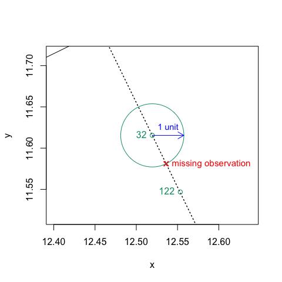

## Proposed coordinates

Using this method of interpolation, I get the following results.

For the two “missing” cases at 40 Broad Street, I move two duplicates, cases 91 and 93, from Cambridge Street:

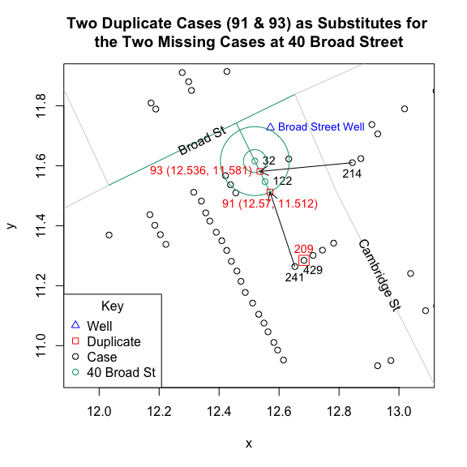

For the missing case at 15 Noel Street, I move the remaining duplicate, case 209, from Cambridge Street:

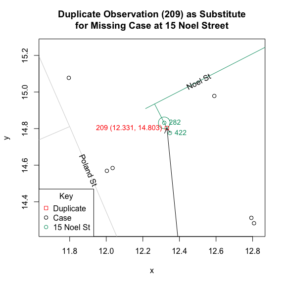

## Notes

[^1]: The map was originally published in Snow’s 1855 book, “On The Mode Of Communication Of Cholera”, and was reprinted as John Snow et. al., 1936. *Snow on Cholera: Being a Reprint of Two Papers*. New York: The Common Wealth Fund. You can also find the map online (a high resolution version is available at http://www.ph.ucla.edu/epi/snow/highressnowmap.html) and in many books, including Edward Tufte’s 1997 “Visual Explanations: Images and Quantities, Evidence and Narrative”.
[^2]: http://www.ncgia.ucsb.edu/pubs/snow/snow.html
[^3]: There is a lack of consensus about the actual number of cases represented in Snow’s map. For what it’s worth, I manually recounted the data on Snow’s map and the result I got matches Dodson and Tobler’s count.
[^4]: For an explanation on how the home road segment is identified, see the “Unstacking Snow Deaths” vignette.